# Coursera Machine learning Assignment

Karlan Astrego

17 maart 2015

## Synopsis

In this paper I will use the Random Forest algorithm on the data from the Weight Lifting Dataset. With the algorithm I will try to predict the activities on a subset of the variables. In the appendix you will find all the R code.

## Explore and prepare the data

First I loaded the data with all the default options. The result is a data frame with 160 features/variables and 19622 rows. It is rather large but there are a lot of variables with many NA’s, empty records and with the value #DIV/0!. This last one is a typicall error code from Microsoft Excel. It often means that there went something wrong with the formula in the specific cell. I will treat the empty records and the cells with the error code as NA’s.

Second, I loaded the data again in a data frame but now I have turned the empty records and the records with #DIV/0! into NA’s. Now there are a lot of features that exists mostly out of NA’s. For instance the variable avg_pitch_forearm has 19216 NA’s out of 19622 records that means that 98% of the records are useless and there are many more of these sort of variables in this dataset, so I decided to remove those.

After removing the features with the NA’s, there are 60 colums left. This little action cleaned the data in a nice way but I wasn’t satisfied, yet.

```
        A         B         C         D         E
0.2843747 0.1935073 0.1743961 0.1638977 0.1838243
```

As you can see, the set is a bit unbalanced. More records fall in the “A” class compared to the other classes but every class has a substantial portion of records. So I don’t worry too much about it. The dataset is ready to go..

## Methodology

As the classes are known, I will use a supervised machine learning algorithm. I chose for the Random Forest algorithm because it handles a big dataset with a lot of features well. The downside is that the final model will lack some interpretability but that is not a big problem here because the main goal is to get an accurate prediction.

The Random Forest is also great for feature selection. I wanted to see if I could shrink the amount of features. Because of that I divided the data set in three parts. The dataset is rather large so I think this will not be a big problem. A big advantage is, when cross validating (more on that later), the computing time is much shorter.

First, I divided the tidy dataset two sets. I reserved 20% of the data for a test set.

Second, the remaining 80% is divided in a set for feature selection (50%) and a final training set (50%).

#### Fitting the model

1. I fitted a Random Forest model with ntree=1000 on the set for feature selection.
2. With the results of step 1, I narrowed down the number of features (I will be using only the most important features) and the number of trees.
3. Fit a Random Forest model on the training set. I used the caret package for this. I did a cross validation with 5 folds and this will be repeated 5 times.
4. Used the trained model for prediction on the test set.

## Results feature selection

In the Variable Importance plot, you can see that there some features a whole lot more important than others. The dots that are more to the right are the most important. I chose a cut off level of a Mean Decrease Accuracy of 50 ( a bit arbitrary). For the final model I will use the following 7 features; yaw_belt, num_window, roll_belt, pitch_belt, magnet_dumbbell_z, magnet_dumbbell_y, pitch_forearm.

In the plot of the Error rate/OOB you can see that the Out of Box error rate (the black line) is decreasing when the number of trees grows. Due to the long computing time when I do cross validation I chose a fairly low number of trees (ntree = 350) for my final model.

The Out of Box error rate (OOB) is 0.7% which looks promising because according to the theory the OOB is a reasonbly good estimate for the out of sample error rate.

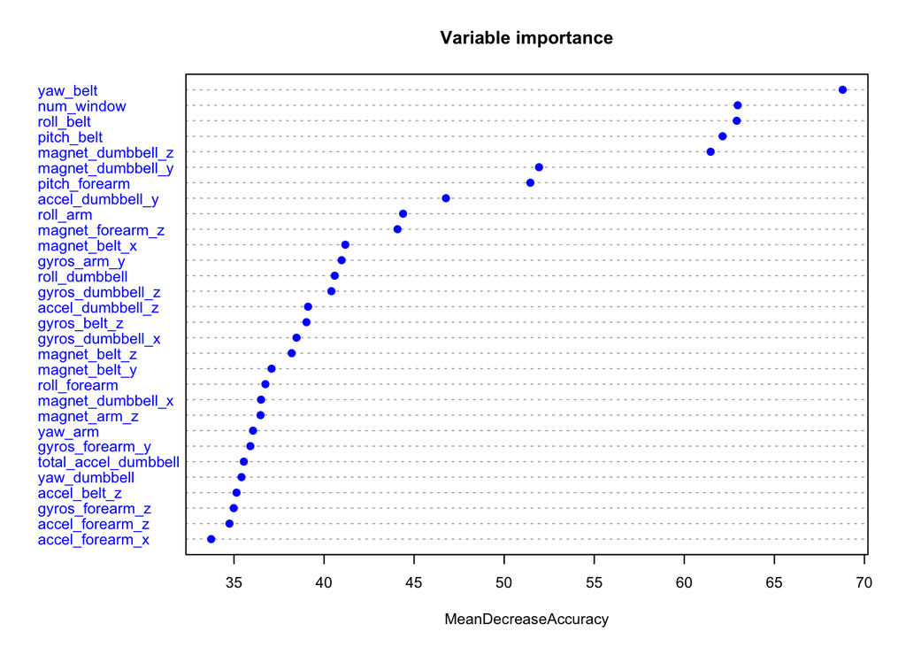

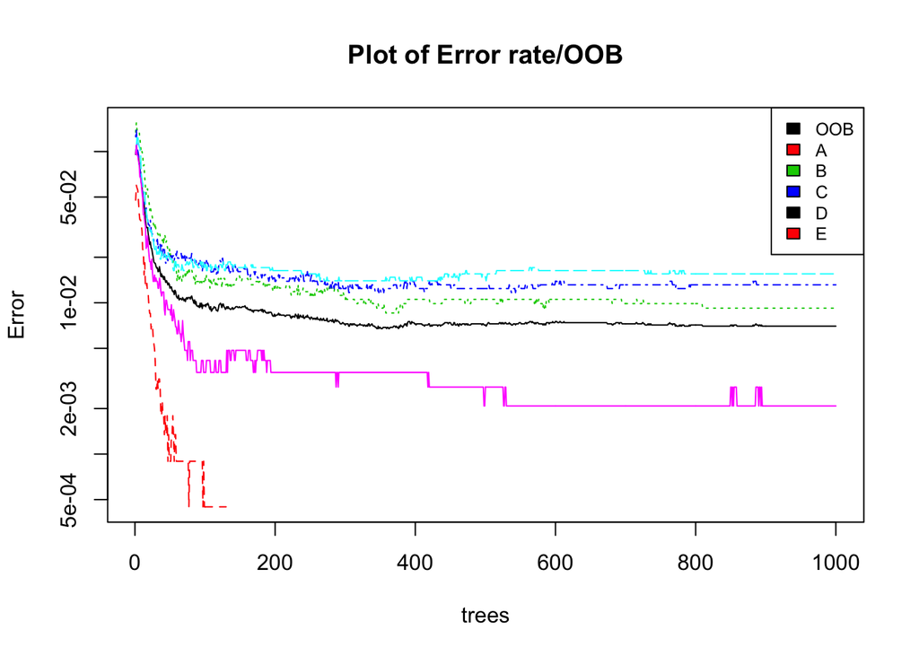

```
Call:
 randomForest(formula = classe ~ ., data = trainset1, importance = TRUE,      do.trace = TRUE, ntree = 1000, prox = TRUE)
               Type of random forest: classification
                     Number of trees: 1000
No. of variables tried at each split: 7

        OOB estimate of  error rate: 0.7%
Confusion matrix:
     A    B    C    D    E class.error
A 2232    0    0    0    0 0.000000000
B   11 1505    3    0    0 0.009216590
C    0   16 1351    2    0 0.013148283
D    0    0   19 1267    1 0.015540016
E    0    0    0    3 1440 0.002079002
```

## Fitting the final model

[output not shown]

## Prediction on the test data set

```
Confusion Matrix and Statistics

          Reference
Prediction    A    B    C    D    E
         A 1116    4    0    0    0
         B    0  750    1    0    1
         C    0    4  683    0    0
         D    0    1    0  643    5
         E    0    0    0    0  715

Overall Statistics

               Accuracy : 0.9959
                 95% CI : (0.9934, 0.9977)
    No Information Rate : 0.2845
    P-Value [Acc > NIR] : < 2.2e-16

                  Kappa : 0.9948
 Mcnemar's Test P-Value : NA

Statistics by Class:

                     Class: A Class: B Class: C Class: D Class: E
Sensitivity            1.0000   0.9881   0.9985   1.0000   0.9917
Specificity            0.9986   0.9994   0.9988   0.9982   1.0000
Pos Pred Value         0.9964   0.9973   0.9942   0.9908   1.0000
Neg Pred Value         1.0000   0.9972   0.9997   1.0000   0.9981
Prevalence             0.2845   0.1935   0.1744   0.1639   0.1838
Detection Rate         0.2845   0.1912   0.1741   0.1639   0.1823
Detection Prevalence   0.2855   0.1917   0.1751   0.1654   0.1823
Balanced Accuracy      0.9993   0.9938   0.9987   0.9991   0.9958
```

#### Just to be sure

I also included the results of the prediction on the data from “pml-testing.csv”. It is not completely clear that it is necessary in the assignment.

```
 [1] B A B A A E D B A A B C B A E E A B B B
Levels: A B C D E
```

## APPENDIX

#### The code for reading the data and cleaning the data

```r
setwd("~/Documents/Rstudio/Coursera/ML")
library(randomForest)
library(caret)
dftraining <- read.csv("pml-training.csv",na.strings=c("NA","#DIV/0!", " "))
dfTrNa <- dftraining[ , apply(dftraining, 2, function(x) !any(is.na(x)))] #verwijdert kolommen met NA
dfEind <- dfTrNa[,7:60]
set<-createDataPartition(y=dfEind$classe,p=0.8,list=FALSE)
set1 = dfEind[ set,]
testing = dfEind[-set,]

classe_table<- table(dfEind$classe) # The propability table
prop.table(classe_table)
```

#### The code for the feature selection and the plots

```r
set<-createDataPartition(y=dfEind$classe,p=0.8,list=FALSE)
set1 = dfEind[ set,]
testing = dfEind[-set,]
InTrain<-createDataPartition(y=set1$classe,p=0.5,list=FALSE)
trainset1 <- set1[InTrain,]
finalset <- set1[-InTrain,]
set.seed(300)
fit <- randomForest(classe ~ .,data=trainset1,importance=TRUE,do.trace=TRUE,ntree=1000, prox=TRUE)
# Plot for the most important features
varImpPlot(fit,type=1,pch=19, main="Variable importance", color="blue", cex=0.7)
# Error rate plot/OOB
plot(fit, log="y",type="l", main="Plot of Error rate/OOB")
legend("topright", colnames(fit$err.rate),col=1:4,cex=0.8,fill=1:4)
fit
```

#### The code for the final model,the prediction on the test data and pml-testing.csv

```r
#Training the final model
ctrl <- trainControl(method = "repeatedcv", number = 5, repeats = 5)
finmod <- train(classe ~ yaw_belt + num_window + roll_belt + magnet_dumbbell_z + pitch_belt + magnet_dumbbell_y + pitch_forearm,method="rf",data=finalset, metric="Accuracy",trControl = ctrl, prox=TRUE, do.trace=TRUE,allowParallel=TRUE,ntree=350)
#Prediction
prediction <- predict(finmod, testing)
confusionMatrix(prediction, testing$classe)
#Prediction on pml-testing.csv
dftest <- read.csv("pml-testing.csv",na.strings=c("NA","#DIV/0!", " "))
dfTestNa <- dftest[ , apply(dftest, 2, function(x) !any(is.na(x)))]
dfTestEind <- dfTestNa[,6:59]
modpred2<- predict(finmod, dfTestEind)
```